# HW 01 - Data wrangling and visualization

due 9-17 at 11:59 PM

Scott Burstein

09/17/2020

# Load Packages

```r
library(tidyverse)
```

```r
lego_sales <- read_csv("data/lego_sales.csv")
view(lego_sales)
```

1. What are the three most common first names of purchasers?

```r
mostCommon1stNames <- lego_sales %>%
  count(first_name) %>%
  arrange(desc(n)) %>%
  top_n(3) #comment out to see the full list sorted in descending order
mostCommon1stNames
```

```
## # A tibble: 3 x 2
##   first_name     n
##   <chr>      <int>
## 1 Jackson       13
## 2 Jacob         11
## 3 Joseph        11
```

The three most common first names of purchasers are Jackson, Jacob and Joseph with counts n = 13, 11 and 11 respectively.

2. What are the three most common themes of lego sets purchased?

```r
mostCommonSetThemes <- lego_sales %>%
  count(theme) %>%
  arrange(desc(n)) %>%
  top_n(3) #comment out to see the full list sorted in descending order
mostCommonSetThemes
```

```
## # A tibble: 4 x 2
##   theme            n
##   <chr>        <int>
## 1 Star Wars       75
## 2 Nexo Knights    64
## 3 Gear            55
## 4 Mixels          55
```

The three most common Lego set themes purchased are Star Wars (n=75), Nexo Knights (n=64), and, tied for 3rd, Gear and Mixels (n=55).

3. Among the most common theme of lego sets purchased, what is the most common subtheme?

```r
#The most common set theme can be determined from running above code chunk and
#determining theme with greatest n.
#For more explicit needs, the following will also return the most popular theme:
# mostCommonSetThemes %>% top_n(1) %>% select(theme)

mostCommonSubtheme <- lego_sales %>%
  filter(theme == 'Star Wars') %>%
  #Can modify theme input to view most common subtheme for different theme.
  count(subtheme) %>%
  arrange(desc(n)) %>%
  top_n(1) #comment out to see the full list sorted in descending order
mostCommonSubtheme
```

```
## # A tibble: 1 x 2
##   subtheme              n
##   <chr>             <int>
## 1 The Force Awakens    15
```

The most common subtheme within the Star Wars theme was ‘The Force Awakens’ with n = 15.

4. Create a new variable called `age_group` and group the ages into the following categories: “18 and under”, “19 - 25”, “26 - 35”, “36 - 50”, “51 and over”.

**Be sure to save the updated data set so you can use the new variable in other questions.**

```r
lego_sales <- lego_sales %>%
  mutate(age_group =
           case_when(
             age <= 18 ~ "18 and under",
             age <= 25 ~ "19-25",
             age <= 35 ~ "26-35",
             age <= 50 ~ "36-50",
             TRUE ~ "51 and over"
             )
         )
```

5. What is the probability a randomly selected customer
   - Is in the 19 - 25 age group?
   - Is in the 19 - 25 age group **and** purchased a Duplo set?
   - Is in the 19 - 25 age group **given** they purchased a Duplo set?

```r
#-----------------------------------
#Probability_1

#P(19-25) = (19-25 age group) / total

P1 <- lego_sales %>%
  count(age_group)  %>%
  mutate(age_props = n / sum(n)) %>%
  filter(age_group == "19-25")
P1
```

```
## # A tibble: 1 x 3
##   age_group     n age_props
##   <chr>     <int>     <dbl>
## 1 19-25       129     0.208
```

```r
#P(19-25) = 129 / 620 = 0.2080645

#-----------------------------------
#Probability_2

#P(19-25 & purchased Duplo set) = (19-25 & purchased Duplo set) / total
#not necessarily independent events.

P2 <- lego_sales %>%
  count(age_group, theme)  %>%
  mutate(age_props = n / sum(n)) %>%
  filter(age_group == "19-25", theme == "Duplo")
P2
```

```
## # A tibble: 1 x 4
##   age_group theme     n age_props
##   <chr>     <chr> <int>     <dbl>
## 1 19-25     Duplo     9    0.0145
```

```r
#P(19-25 & purchased Duplo set) = 9 / 620 = 0.01451613

#-----------------------------------
#Probability_3

#P(19-25 GIVEN purchased Duplo set) =
#P(19-25 & purchased Duplo set) / P(purchased a Duplo set)

P_duplo <- lego_sales %>%
  count(theme)  %>%
  mutate(theme_props = n / sum(n)) %>%
  filter(theme == "Duplo")
P_duplo
```

```
## # A tibble: 1 x 3
##   theme     n theme_props
##   <chr> <int>       <dbl>
## 1 Duplo    35      0.0565
```

```r
#P_duplo = 35 / 620 = 0.05645161

P3 <- 9 / 35
P3
```

```
## [1] 0.2571429
```

```r
#P3 = P2 / P_duplo = 0.01451613 / 0.05645161 = 0.2571429
```

The probability that a customer is in the 19 - 25 age group is 0.2080645.

The probability that a customer is in the 19 - 25 age group and purchased a Duplo set is 0.01451613.

The probability that a customer is in the 19 - 25 age group given that they purchased a Duplo set is 0.2571429.

6. Which age group has purchased the largest number of lego sets? How many did they purchase?

```r
age_group_most_purchases <- lego_sales %>%
  group_by(age_group) %>%
  summarise(quantity_purchased = sum(quantity)) %>%
  arrange(desc(quantity_purchased)) %>%
  top_n(1) #comment out to see the full list sorted in descending order
age_group_most_purchases
```

```
## # A tibble: 1 x 2
##   age_group quantity_purchased
##   <chr>                  <dbl>
## 1 36-50                    313
```

The 36-50 age group has purchased the largest number of lego sets. This age group purchased 313 lego sets.

7. Which age group has spent the most money on legos?

```r
age_group_most_money <- lego_sales %>%
  group_by(age_group) %>%
  summarise(total_USD_spent = sum(us_price * quantity)) %>%
  arrange(desc(total_USD_spent)) %>%
  top_n(1) #comment out to see the full list sorted in descending order
age_group_most_money
```

```
## # A tibble: 1 x 2
##   age_group total_USD_spent
##   <chr>               <dbl>
## 1 36-50               9533.
```

The 36-50 age group has spent the most total money on purchases of lego sets. This age group has spent $9,532.87 on lego sets.

8. Come up with a question you want to answer using these data, and write it down. Then, create a data visualization that answers the question, and briefly explain how your visualization answers the question.

Does Lego set theme affect price? How well is piece count correlated with price of Lego sets across popular set themes?

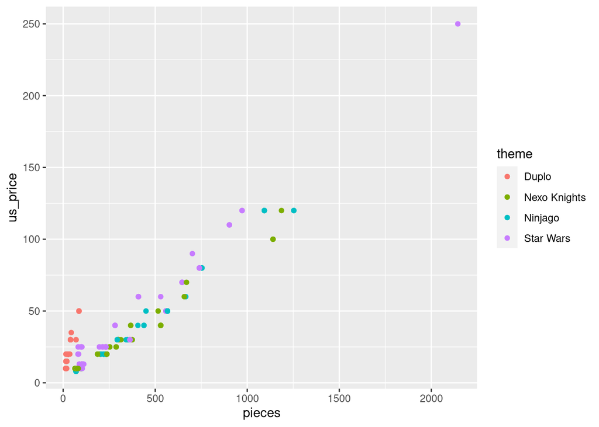

```r
piece_price_corr_viz <-
  lego_sales %>%
  filter(theme %in% c("Duplo", "Ninjago", "Star Wars", "Nexo Knights")) %>%

  ggplot(mapping = aes(x = pieces,
                       y = us_price,
                       color = theme)) +
    geom_point(na.rm = TRUE)

piece_price_corr_viz
```

Chose four of the most popular Lego set themes to analyze: “Duplo”, “Ninjago”, “Star Wars”, and “Nexo Knights”. Plotted the piece count on x-axis and set price on y-axis for sets across different Lego themes. There does appear to be a difference in cost based on set theme.

9. Add one element to the plot from the previous exercise to change the look of the plot without changing the underlying data. For example, you can change the theme, background color, add annotations, etc. State the change you’re making and display the updated visualization. We encourage you to be creative!

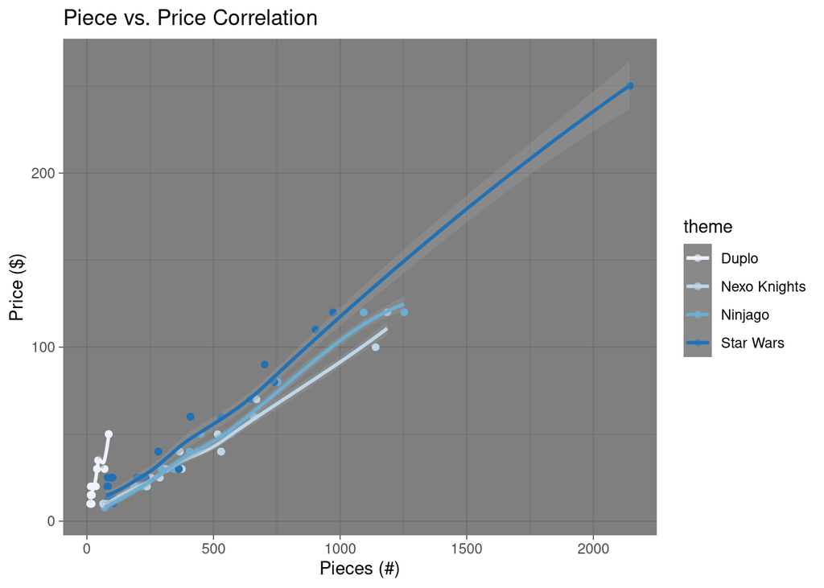

```r
piece_price_corr_viz +
  theme_dark() +
  scale_colour_brewer() +
  labs(x = 'Pieces (#)',
       y = 'Price ($)',
       title = 'Piece vs. Price Correlation'
       ) +
  geom_smooth()
```

Added labs, theme, color and geom_smooth() trendlines to reflect the difference in price per piece count for four of the most popular Lego set themes.

It is evident that Lego does modify set price based on theme. From the visualization, it seems as though the Star Wars theme is usually priced higher than Nexo Knights and Ninjago for any piece count. Another interesting takeaway is that the Duplo theme, while generally having small piece counts, is priced higher per piece than any of the other three set themes for many distinct piece counts.